# Demo Produção

Felipe de S N Coelho

# 1 Início

Bibliotecas necessárias:

```r
# install.packages("tidyverse")
# install.packages("fmsb")
# install.packages("readxl")

library(tidyverse)
library(readxl)
library(fmsb)
```

# 2 Base de dados

Base de dados “produção.xls” utilizada em aula:

```r
df_prod <- read_excel("C:/Users/HP/Documents/R/bases/producao.xls", sheet = "Plan1")

df_prod
```

| Máquina | Setor | Operador | Data Ocorrência | Hora | Tipo problema | Horas Paradas | Custo-hora | Custo total da falha |
| --- | --- | --- | --- | --- | --- | --- | --- | --- |
| empilhadeira | produção | João Maria | 2000-07-30 | 9 | falta peças | 2 | 50 | 100 |
| empilhadeira | produção | João Maria | 2000-07-30 | 9 | falta peças | 1 | 50 | 50 |
| empilhadeira | produção | João Maria | 2000-07-30 | 9 | falta peças | 2 | 50 | 100 |
| computador | almoxarife | Beltrão | 2003-08-12 | 9 | falta software | 2 | 10 | 20 |
| computador | almoxarife | Rudinei | 2003-09-16 | 7 | falta software | 3 | 10 | 30 |
| computador | almoxarife | Rudinei | 2003-09-16 | 7 | falta software | 4 | 10 | 40 |
| computador | almoxarife | Rudinei | 2003-09-16 | 7 | não liga | 5 | 10 | 50 |
| computador | almoxarife | Rudinei | 2003-09-16 | 7 | não liga | 1 | 10 | 10 |
| computador | almoxarife | Rudinei | 2003-09-16 | 7 | não liga | 2 | 10 | 20 |
| computador | almoxarife | Rudinei | 2003-11-08 | 7 | não liga | 1 | 10 | 10 |

[output cut: 136 more lines]

Dataset tipo *tibble* com 146 linhas (ie., observações) e 9 colunas (ie., variáveis).

# 3 Preparação dos dados

## 3.1 Inspeção básica

```r
head(df_prod)
```

| Máquina | Setor | Operador | Data Ocorrência | Hora | Tipo problema | Horas Paradas | Custo-hora | Custo total da falha |
| --- | --- | --- | --- | --- | --- | --- | --- | --- |
| empilhadeira | produção | João Maria | 2000-07-30 | 9 | falta peças | 2 | 50 | 100 |
| empilhadeira | produção | João Maria | 2000-07-30 | 9 | falta peças | 1 | 50 | 50 |
| empilhadeira | produção | João Maria | 2000-07-30 | 9 | falta peças | 2 | 50 | 100 |
| computador | almoxarife | Beltrão | 2003-08-12 | 9 | falta software | 2 | 10 | 20 |
| computador | almoxarife | Rudinei | 2003-09-16 | 7 | falta software | 3 | 10 | 30 |
| computador | almoxarife | Rudinei | 2003-09-16 | 7 | falta software | 4 | 10 | 40 |

> *df* refere-se a um *data frame* de modo geral.

```r
tail(df_prod) # show last 5
```

| Máquina | Setor | Operador | Data Ocorrência | Hora | Tipo problema | Horas Paradas | Custo-hora | Custo total da falha |
| --- | --- | --- | --- | --- | --- | --- | --- | --- |
| empilhadeira | produção | José Carlos | 2004-08-08 | 16 | travou entrada | 5 | 50 | 250 |
| empilhadeira | produção | José Carlos | 2004-08-08 | 16 | travou entrada | 1 | 50 | 50 |
| empilhadeira | produção | José Carlos | 2004-08-08 | 16 | travou entrada | 1 | 50 | 50 |
| empilhadeira | produção | José Carlos | 2007-07-03 | 16 | travou entrada | 12 | 50 | 600 |
| empilhadeira | produção | Otto | 2007-07-03 | 16 | travou entrada | 1 | 50 | 50 |
| empilhadeira | produção | Menezes | 2007-07-03 | 16 | travou entrada | 2 | 50 | 100 |

O comando **names**(df) retorna um array de strings contendo o nome de cabeçalho de cada variável, ie. coluna:

```r
names(df_prod)
```

```
[1] "Máquina"              "Setor"                "Operador"
[4] "Data Ocorrência"      "Hora"                 "Tipo problema"
[7] "Horas Paradas"        "Custo-hora"           "Custo total da falha"
```

Assim, temos uma visão geral das variáveis presentes.

O comando **summary**(df) nos fornece algumas informações sobre a base de dados e uma noção estatística dos valores.

```r
summary(df_prod)
```

```
   Máquina             Setor             Operador
 Length:146         Length:146         Length:146
 Class :character   Class :character   Class :character
 Mode  :character   Mode  :character   Mode  :character



 Data Ocorrência                    Hora       Tipo problema
 Min.   :2000-07-30 00:00:00   Min.   : 7.00   Length:146
 1st Qu.:2004-01-27 00:00:00   1st Qu.: 8.00   Class :character
 Median :2004-04-01 00:00:00   Median : 9.00   Mode  :character
 Mean   :2004-03-23 13:09:02   Mean   :10.92
 3rd Qu.:2004-05-29 06:00:00   3rd Qu.:14.00
 Max.   :2007-07-03 00:00:00   Max.   :19.00
 Horas Paradas     Custo-hora    Custo total da falha
 Min.   : 1.00   Min.   :10.00   Min.   :  10.0
 1st Qu.: 1.00   1st Qu.:10.00   1st Qu.:  20.0
 Median : 2.00   Median :50.00   Median :  50.0
 Mean   : 3.00   Mean   :33.97   Mean   : 110.5
 3rd Qu.: 3.75   3rd Qu.:50.00   3rd Qu.: 150.0
 Max.   :20.00   Max.   :50.00   Max.   :1000.0
```

## 3.2 Edições necessárias

### 3.2.1 Eliminando espaços

Trabalhando com R, devemos eliminar os espaços " " entre palavras nos nomes das colunas. Neste caso, substituiremos com "_":

```r
colnames(df_prod) <- names(df_prod) %>%
    str_replace_all(c(" " = "_"))

names(df_prod)
```

```
[1] "Máquina"              "Setor"                "Operador"
[4] "Data_Ocorrência"      "Hora"                 "Tipo_problema"
[7] "Horas_Paradas"        "Custo-hora"           "Custo_total_da_falha"
```

### 3.2.2 Separando datas e hora

Numa base de dados, muitas vezes temos apenas uma coluna, ou duas, contendo informações de data e hora de cada observação. Tendo data com dia, mês e ano (não necessariamnte nesta ordem) será conveniente separarmos cada informação e, ainda, obter o dia da semana de cada observação para fins de análise.

Para isso, primeiro definimos o formato da data tal como consta em df_prod$Data_Ocorrência, neste caso, *ano-mês-dia*:

```r
ymd <- "([0-9]{4})[-]([0-9]{2})[-]([0-9]{2})" # pattern yyyy-mm-dd
```

O padrão definido em *ymd* será então passado a um método (ou função) de comparação de strings. O método **str_match**() encarregar-se-á de particionar a string contendo a data. E o resultado será guardado em um novo df contendo os dados originais na primeira coluna e, nas colunas subsequêntes, as respectivas partições respeitando o padrão definido em *ymd*.

```r
df_dates <- as.data.frame(str_match(df_prod$Data_Ocorrência, ymd))

colnames(df_dates) <- c("Data", "Ano", "Mes", "Dia")

head(df_dates)
```

|  | Data | Ano | Mes | Dia |
| --- | --- | --- | --- | --- |
| 1 | 2000-07-30 | 2000 | 07 | 30 |
| 2 | 2000-07-30 | 2000 | 07 | 30 |
| 3 | 2000-07-30 | 2000 | 07 | 30 |
| 4 | 2003-08-12 | 2003 | 08 | 12 |
| 5 | 2003-09-16 | 2003 | 09 | 16 |
| 6 | 2003-09-16 | 2003 | 09 | 16 |

Podemos ainda determinar o dia da semana como segue:

```r
# converte datas em formato strings para um formato apropriado
x_datas <- as.Date(df_dates$Data)

# define um df contendo o dia da semana abreviado
Dia_semana <- weekdays(x_datas, abbreviate = TRUE)
df_dates <- df_dates %>%
  mutate(as.data.frame(Dia_semana))

head(df_dates)
```

|  | Data | Ano | Mes | Dia | Dia_semana |
| --- | --- | --- | --- | --- | --- |
| 1 | 2000-07-30 | 2000 | 07 | 30 | Sun |
| 2 | 2000-07-30 | 2000 | 07 | 30 | Sun |
| 3 | 2000-07-30 | 2000 | 07 | 30 | Sun |
| 4 | 2003-08-12 | 2003 | 08 | 12 | Tue |
| 5 | 2003-09-16 | 2003 | 09 | 16 | Tue |
| 6 | 2003-09-16 | 2003 | 09 | 16 | Tue |

Para facilitar a correta ordem dos dias da semana nos plots, podemos mapear os dias da semana com uma numeração conveniente como ‘01’ para domingo (Sun), ‘02’ para segunda (Mon), e assim por diante.

```r
df_dates <- df_dates %>%
    mutate(Dia_n = case_when(Dia_semana == "Sun" ~ "01",
                             Dia_semana == "Mon" ~ "02",
                             Dia_semana == "Tue" ~ "03",
                             Dia_semana == "Wed" ~ "04",
                             Dia_semana == "Thu" ~ "05",
                             Dia_semana == "Fri" ~ "06",
                             Dia_semana == "Sat" ~ "07",
                             TRUE ~ "00" # para qualquer outro valor
                             )
           )

head(df_dates)
```

|  | Data | Ano | Mes | Dia | Dia_semana | Dia_n |
| --- | --- | --- | --- | --- | --- | --- |
| 1 | 2000-07-30 | 2000 | 07 | 30 | Sun | 01 |
| 2 | 2000-07-30 | 2000 | 07 | 30 | Sun | 01 |
| 3 | 2000-07-30 | 2000 | 07 | 30 | Sun | 01 |
| 4 | 2003-08-12 | 2003 | 08 | 12 | Tue | 03 |
| 5 | 2003-09-16 | 2003 | 09 | 16 | Tue | 03 |
| 6 | 2003-09-16 | 2003 | 09 | 16 | Tue | 03 |

Agora podemos acrescentar os novos dados referentes à data e dia, dispensando a coluna original ‘Data_Ocorrência’ pois esta não será mais necessária.

```r
df_new <- df_prod %>%
    # add new cols
    mutate(df_dates) %>%
    # drop existing col
    select(-Data_Ocorrência)

head(df_new)
```

| Máquina | Setor | Operador | Hora | Tipo_problema | Horas_Paradas | Custo-hora | Custo_total_da_falha | Data | Ano | Mes | Dia | Dia_semana | Dia_n |
| --- | --- | --- | --- | --- | --- | --- | --- | --- | --- | --- | --- | --- | --- |
| empilhadeira | produção | João Maria | 9 | falta peças | 2 | 50 | 100 | 2000-07-30 | 2000 | 07 | 30 | Sun | 01 |
| empilhadeira | produção | João Maria | 9 | falta peças | 1 | 50 | 50 | 2000-07-30 | 2000 | 07 | 30 | Sun | 01 |
| empilhadeira | produção | João Maria | 9 | falta peças | 2 | 50 | 100 | 2000-07-30 | 2000 | 07 | 30 | Sun | 01 |
| computador | almoxarife | Beltrão | 9 | falta software | 2 | 10 | 20 | 2003-08-12 | 2003 | 08 | 12 | Tue | 03 |
| computador | almoxarife | Rudinei | 7 | falta software | 3 | 10 | 30 | 2003-09-16 | 2003 | 09 | 16 | Tue | 03 |
| computador | almoxarife | Rudinei | 7 | falta software | 4 | 10 | 40 | 2003-09-16 | 2003 | 09 | 16 | Tue | 03 |

# 4 Visualização de dados

A partir das questões dadas em aula, podemos realizar a visualização dos dados por gráficos. Gráficos são recursos que podem auxiliar muito na análise e interpretação dos dados antes da tomada de decisão, sem necessidade de ferramentas muito sofisticadas de Data Mining.

Utilizei apenas gráficos de colunas por conveniência.

## 4.1 Questões

### 4.1.1 Qual o tipo de falha mais comum antes das 12h X depois das 12h?

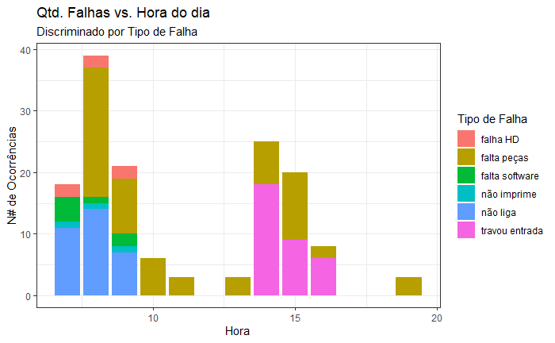

```r
p1a <- ggplot(df_new, aes(x=Hora,
                          fill=Tipo_problema)) +
    geom_bar(position = "stack") +
    # edit titles and labels
    labs(x = "Hora",
         y = "N# de Ocorrências",
         title ="Qtd. Falhas vs. Hora do dia",
         subtitle = "Discriminado por Tipo de Falha") +
    guides(fill = guide_legend(title = "Tipo de Falha")) +
    theme(legend.position = "top") +
    # edit chart box and labels
    theme_bw()

show(p1a)
```

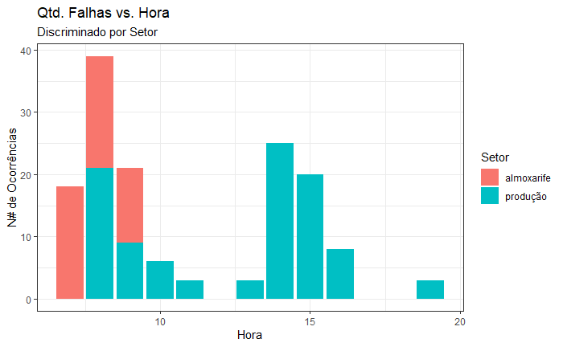

```r
p1b <- ggplot(df_new, aes(x=Hora,
                          fill=Setor)) +
    geom_bar(position = "stack") +
    # edit titles and labels
    labs(x = "Hora",
         y = "N# de Ocorrências",
         title ="Qtd. Falhas vs. Hora",
         subtitle = "Discriminado por Setor") +
    guides(fill = guide_legend(title = "Setor")) +
    theme(legend.position = "top")  +
    # edit chart box and labels
    theme_bw()

show(p1b)
```

### 4.1.2 Encontrar relação entre dia da semana X tipo de falha.

O gráfico abaixo nos mostra que:

1. Domingo, terças- e quintas-feiras são os dias em que ocorrem mais falhas, seguido por sextas-feiras e sábados;
2. E falhas devido ao travamento da entrada ocorrem todos os dias.

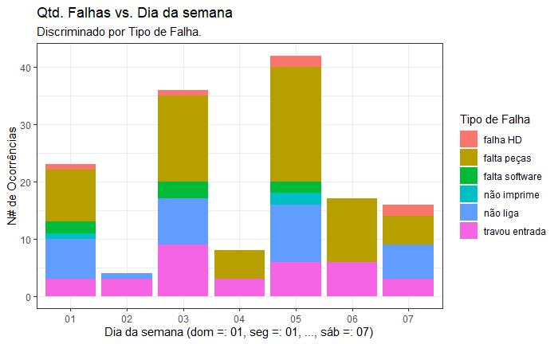

```r
p2a <- ggplot(df_new, aes(x=Dia_n,
                          fill=Tipo_problema)) +
    geom_bar(position = "stack") +
    # edit titles and labels
    labs(x = "Dia da semana (dom =: 01, seg =: 01, ..., sáb =: 07)",
         y = "N# de Ocorrências",
         title ="Qtd. Falhas vs. Dia da semana",
         subtitle = "Discriminado por Tipo de Falha.") +
    guides(fill = guide_legend(title = "Tipo de Falha")) +
    theme(legend.position = "top") +
    # edit chart box and labels
    theme_bw()

show(p2a)
```

Entretanto, se levarmos em consideração as informações de dia, mês e ano, podemos ter uma visão melhor sobre a ocorrência de falhas, como mostra o gráfico abaixo:

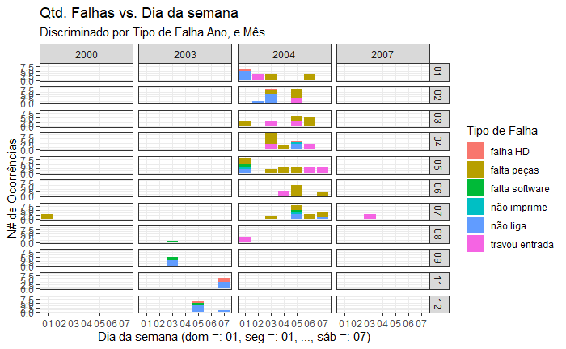

```r
p2b <- ggplot(df_new, aes(x=Dia_n,
                         fill=Tipo_problema)) +
    geom_bar(position = "stack") +
    facet_grid(vars(Mes), vars(Ano)) +
    # edit titles and labels
    labs(x = "Dia da semana (dom =: 01, seg =: 01, ..., sáb =: 07)",
         y = "N# de Ocorrências",
         title ="Qtd. Falhas vs. Dia da semana",
         subtitle = "Discriminado por Tipo de Falha Ano, e Mês.") +
    guides(fill = guide_legend(title = "Tipo de Falha")) +
    theme(legend.position = "top") +
    # edit chart box and labels
    theme_bw()

show(p2b)
```

> É claro que, num caso real onde muito mais dados são coletados, dificilmente teríamos meses e anos tão *tranquilos*, como em 2000 e 2003, a menos que os devidos dados não eram coletados até 2004, mas isso também não explica o caso de 2007 o qual deveria, muito provavelmente, apresentar mais ocorrências de falhas.

### 4.1.3 Encontrar relação entre dia da semana X setor

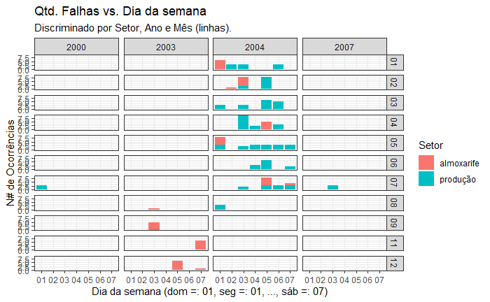

```r
p3 <- ggplot(df_new, aes(x=Dia_n,
                         fill=Setor)) +
    geom_bar(position = "stack") +
    facet_grid(vars(Mes), vars(Ano)) +
    # edit titles and labels
    labs(x = "Dia da semana (dom =: 01, seg =: 01, ..., sáb =: 07)",
         y = "N# de Ocorrências",
         title ="Qtd. Falhas vs. Dia da semana",
         subtitle = "Discriminado por Setor, Ano e Mês (linhas)." ) +
    guides(fill = guide_legend(title = "Setor")) +
    theme(legend.position = "top") +
    # edit chart box and labels
    theme_bw()

show(p3)
```

### 4.1.4 Encontrar relação entre dia da semana x operador

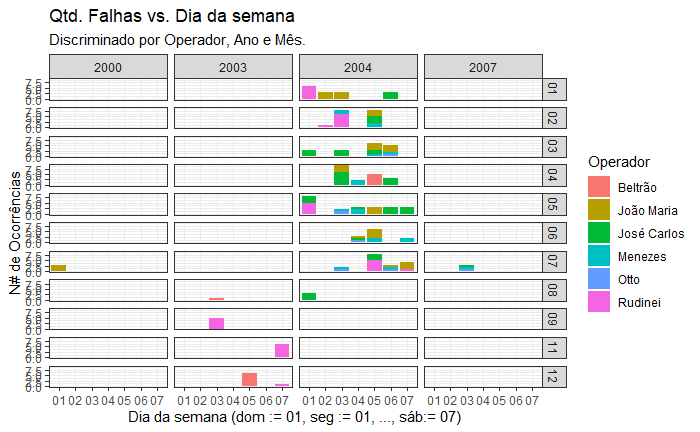

```r
p4 <- ggplot(df_new, aes(x=Dia_n,
                        fill=Operador)) +
    geom_bar(position = "stack") +
    facet_grid(vars(Mes), vars(Ano)) +
    # edit titles and labels
    labs(x = "Dia da semana (dom := 01, seg := 01, ..., sáb:= 07)",
         y = "N# de Ocorrências",
         title ="Qtd. Falhas vs. Dia da semana",
         subtitle = "Discriminado por Operador, Ano e Mês.") +
    guides(fill = guide_legend(title = "Operador")) +
    theme(legend.position = "top") +
    # edit chart box and labels
    theme_bw()

show(p4)
```

### 4.1.5 Qual o tipo de falha que deixa mais tempo a produção parada

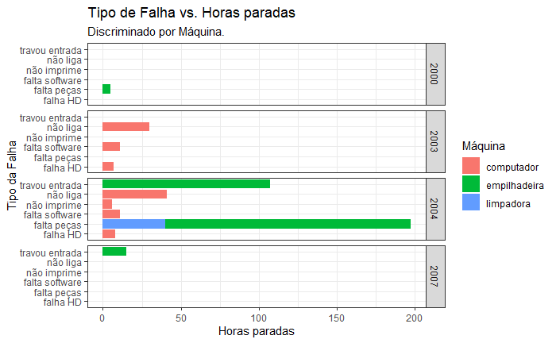

```r
p5a <- ggplot(df_new, aes(x=Horas_Paradas,
                          y=Tipo_problema,
                          fill=Máquina)) +
  geom_col(position = "stack") +
  facet_grid(vars(Ano)) +
  # edit titles and labels
  labs(x = "Horas paradas",
       y = "Tipo da Falha",
       title ="Tipo de Falha vs. Horas paradas",
       subtitle = "Discriminado por Máquina.") +
  guides(fill = guide_legend(title = "Máquina")) +
  theme(legend.position = "top") +
  # edit chart box and labels
  theme_bw()

show(p5a)
```

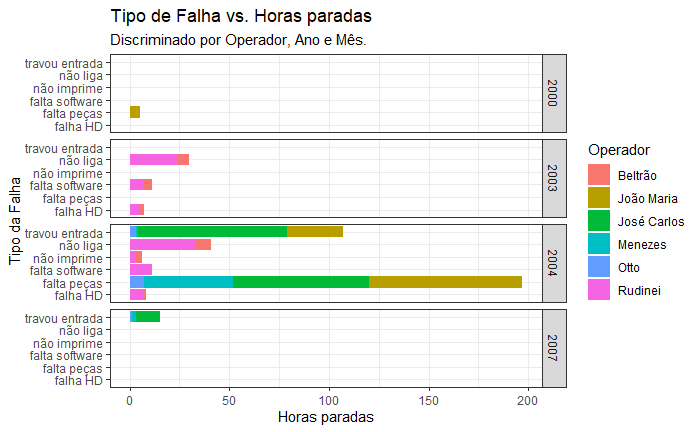

```r
p5b <- ggplot(df_new, aes(x=Horas_Paradas,
                         y=Tipo_problema,
                         fill=Operador)) +
    geom_col(position = "stack") +
    facet_grid(vars(Ano)) +
    # edit titles and labels
    labs(x = "Horas paradas",
         y = "Tipo da Falha",
         title ="Tipo de Falha vs. Horas paradas",
         subtitle = "Discriminado por Operador, Ano e Mês.") +
    guides(fill = guide_legend(title = "Operador")) +
    theme(legend.position = "top") +
    # edit chart box and labels
    theme_bw()

show(p5b)
```

# 5 Conclusão

1. Não precisamos demitir Rudinei,
2. Mas talvez João Maria, José Carlos e Menezes.
3. 2004 foi um ano difícil!

Brincadeira ;-)

# 6 Remarks

Este caderno foi gerado utilizando [R Markdown](http://rmarkdown.rstudio.com).